# Day 3 Lecture

# Pulling from the repo

First time: `git clone https://github.com/shoestringpsycholing/r_programming_bsos.git`

After that: `git pull origin master`

# Some follow-up notes

## `<-` vs. `=`

Both work! Not equivalent!

- the arrow (`<-`) is “more idiomatic” for R
- the single equals (`=`) is more common in other languages
- the arrow **always** means “assignment”
- the single equals does not mean assignment in some places (e.g., inside a function call)
- arguments for arrow:
1. Visually distinctive
2. Always unambiguously means “assignment”
- arguments for single equals:
1. Less typing
2. Common in many other programming languages
- *Final recommendation*: if you have a strong preference, just use that, if not, use arrow

# Notebooks vs. scripts

Sweave: the original “reproducible document”, mix of LaTeX and R

R Markdown: one of the “cutting edge” formats, especially well-integrated into RStudio, that allows mixing of R code with text, document formatting, links, graphics, etc.

The following is a code chunk, and when `knitr()` is run on this document, it will display both the code and the output.

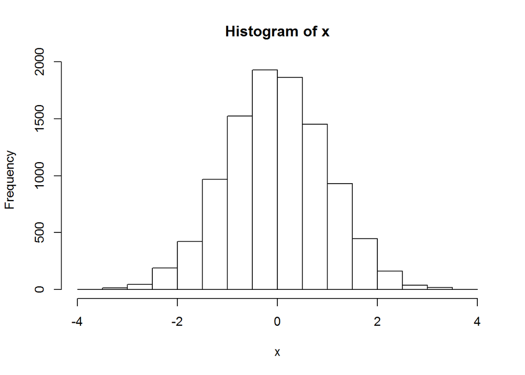

```r
x <- rnorm(10000)
hist(x)  # this is a histogram
```

```r
t.test(x)
```

```
##
##  One Sample t-test
##
## data:  x
## t = -1.1972, df = 9999, p-value = 0.2313
## alternative hypothesis: true mean is not equal to 0
## 95 percent confidence interval:
##  -0.031780139  0.007680201
## sample estimates:
##   mean of x
## -0.01204997
```

You can also insert “inline” results, like the following:

The mean of `x` is -0.01205.

Clicking on the little question mark in the RStudio GUI above this document will point you towards lots of helpful documentation on the details of Markdown and R Markdown documents.

# Reading and writing data/files

## Weird file types

Package for reading Excel data: `xlsx`

Package for other stats packages (SPSS, SAS, Stata): `foreign`

## “Reading” .RData

`load()` puts objects in your workspace

```r
# NOTE: this code block is marked eval = FALSE, so it will not
#       run. This is because the files mentioned are fake, and
#       will produce errors if run.
mydata <- load("otherdata.RData")  # otherdata.RData contains object "foo"

# mydata == "foo"
load("otherdata.RData")  # gets "foo" into your workspace
mydata <- foo # make a new object
```

## Look at the options!

```r
?read.table

mydata <- read.csv(filename, na.strings = c("NA", "N/A", "n/a", " ", "nuthin"))

?readLines
?scan
```

## Writing files!

```r
?write.table # .csv, etc.
```

Catches - rownames!

```r
write.table(mydata, file = "outputfile.txt", sep = "\t",
            row.names = FALSE)  # good for exporting data
```

# Data types

- numeric
- character
- factor
- logical
- NA
- NULL
- others (e.g, “Date”)

## Numeric

- numbers!
- sometimes integers can differ from non-integers
- `as.numeric()` forces it to be a number (not integers)
- `1L` is an integer
- have mean, medians

## Characters

- `as.character()` converts to characters
- more primitive than factors
- can manipulate with regular expressions, other text functions

## Factors

- Actually numbers under the hood
- Act like numbers + labels
- VERY useful for many kinds of analyses
- if a column is a *property* of data (not a measure itself), factors are usually best
  - groupings = good as factors
  - conditions = good as factors
- if a column is *data*, maybe consider keeping it a string
- `as.factor()` coerces to a factor
- `factor()` creates a factor
- factors have *levels*: categories
- `stringsAsFactors` : option for how to read in character vectors
  - = FALSE if you don’t want to read in characters as factors

## Logicals

- TRUE and FALSE
- if coerced to `as.numeric`, TRUE == 1, FALSE == 0
  - can take the mean of a logical vector
- Shortcuts: T and F
  - *DANGER*: T and F can be overwritten
- logical operators create logical vectors
  - `==`
  - `>`
  - `<`
  - `|` This is the “long bar”, meaning (inclusive) “or” (aka “pipe”)
  - `&` == “and”
  - `>=` greater or equal
  - `!` is NOT
  - `&&` and `||` for more specific programming sitauations

```r
3 < 4
```

```
## [1] TRUE
```

```r
sleep
```

```
##    extra group ID
## 1    0.7     1  1
## 2   -1.6     1  2
## 3   -0.2     1  3
## 4   -1.2     1  4
## 5   -0.1     1  5
## 6    3.4     1  6
## 7    3.7     1  7
## 8    0.8     1  8
## 9    0.0     1  9
## 10   2.0     1 10
## 11   1.9     2  1
## 12   0.8     2  2
## 13   1.1     2  3
## 14   0.1     2  4
## 15  -0.1     2  5
## 16   4.4     2  6
## 17   5.5     2  7
## 18   1.6     2  8
## 19   4.6     2  9
## 20   3.4     2 10
```

```r
sleep$extra > 0
```

```
##  [1]  TRUE FALSE FALSE FALSE FALSE  TRUE  TRUE  TRUE FALSE  TRUE  TRUE
## [12]  TRUE  TRUE  TRUE FALSE  TRUE  TRUE  TRUE  TRUE  TRUE
```

```r
which(sleep$extra > 0)
```

```
##  [1]  1  6  7  8 10 11 12 13 14 16 17 18 19 20
```

## NA and NULL (and others)

- `NA` mean “missing value” or “missing data”
- `NULL` means “nothing”, the absence of something
- `Inf` and `-Inf`
- `NaN`

Handling NAs - can be a a huge pain - sometimes `na.rm = TRUE` (like for `mean()`)

```r
x <- c(1, 2, NA, 4, 68)
mean(x)
```

```
## [1] NA
```

```r
mean(x, na.rm = TRUE)
```

```
## [1] 18.75
```

- sometimes it’s other stuff
- `cor()` use = “pairwise.complete.obs”
- no universal “deal with NAs” argument

# More subsetting

## Basics

```r
sleep
```

```
##    extra group ID
## 1    0.7     1  1
## 2   -1.6     1  2
## 3   -0.2     1  3
## 4   -1.2     1  4
## 5   -0.1     1  5
## 6    3.4     1  6
## 7    3.7     1  7
## 8    0.8     1  8
## 9    0.0     1  9
## 10   2.0     1 10
## 11   1.9     2  1
## 12   0.8     2  2
## 13   1.1     2  3
## 14   0.1     2  4
## 15  -0.1     2  5
## 16   4.4     2  6
## 17   5.5     2  7
## 18   1.6     2  8
## 19   4.6     2  9
## 20   3.4     2 10
```

```r
sleep[sleep$group == 1, ]
```

```
##    extra group ID
## 1    0.7     1  1
## 2   -1.6     1  2
## 3   -0.2     1  3
## 4   -1.2     1  4
## 5   -0.1     1  5
## 6    3.4     1  6
## 7    3.7     1  7
## 8    0.8     1  8
## 9    0.0     1  9
## 10   2.0     1 10
```

```r
sleep$group == 1
```

```
##  [1]  TRUE  TRUE  TRUE  TRUE  TRUE  TRUE  TRUE  TRUE  TRUE  TRUE FALSE
## [12] FALSE FALSE FALSE FALSE FALSE FALSE FALSE FALSE FALSE
```

```r
sleep[which(sleep$group == 1), ]
```

```
##    extra group ID
## 1    0.7     1  1
## 2   -1.6     1  2
## 3   -0.2     1  3
## 4   -1.2     1  4
## 5   -0.1     1  5
## 6    3.4     1  6
## 7    3.7     1  7
## 8    0.8     1  8
## 9    0.0     1  9
## 10   2.0     1 10
```

```r
which(sleep$group == 1)
```

```
##  [1]  1  2  3  4  5  6  7  8  9 10
```

```r
sleep[sleep$group == 1 & sleep$extra > 0, ]
```

```
##    extra group ID
## 1    0.7     1  1
## 6    3.4     1  6
## 7    3.7     1  7
## 8    0.8     1  8
## 10   2.0     1 10
```

```r
sleep[sleep$group == 1 | sleep$extra > 0, ]
```

```
##    extra group ID
## 1    0.7     1  1
## 2   -1.6     1  2
## 3   -0.2     1  3
## 4   -1.2     1  4
## 5   -0.1     1  5
## 6    3.4     1  6
## 7    3.7     1  7
## 8    0.8     1  8
## 9    0.0     1  9
## 10   2.0     1 10
## 11   1.9     2  1
## 12   0.8     2  2
## 13   1.1     2  3
## 14   0.1     2  4
## 16   4.4     2  6
## 17   5.5     2  7
## 18   1.6     2  8
## 19   4.6     2  9
## 20   3.4     2 10
```

```r
# "where"
sleep[!sleep$group == 1, ]
```

```
##    extra group ID
## 11   1.9     2  1
## 12   0.8     2  2
## 13   1.1     2  3
## 14   0.1     2  4
## 15  -0.1     2  5
## 16   4.4     2  6
## 17   5.5     2  7
## 18   1.6     2  8
## 19   4.6     2  9
## 20   3.4     2 10
```

```r
sleep[sleep$ID == c(1, 3, 4, 6), ]  # DOESN'T WORK
```

```
##    extra group ID
## 1    0.7     1  1
## 16   4.4     2  6
```

```r
sleep[sleep$ID %in% c(1, 3, 4, 6), ]
```

```
##    extra group ID
## 1    0.7     1  1
## 3   -0.2     1  3
## 4   -1.2     1  4
## 6    3.4     1  6
## 11   1.9     2  1
## 13   1.1     2  3
## 14   0.1     2  4
## 16   4.4     2  6
```

```r
sleep$ID %in% c(1, 3, 4, 6)
```

```
##  [1]  TRUE FALSE  TRUE  TRUE FALSE  TRUE FALSE FALSE FALSE FALSE  TRUE
## [12] FALSE  TRUE  TRUE FALSE  TRUE FALSE FALSE FALSE FALSE
```

```r
sleep[!sleep$ID %in% c(1, 3, 4, 6), ]  # "not in"
```

```
##    extra group ID
## 2   -1.6     1  2
## 5   -0.1     1  5
## 7    3.7     1  7
## 8    0.8     1  8
## 9    0.0     1  9
## 10   2.0     1 10
## 12   0.8     2  2
## 15  -0.1     2  5
## 17   5.5     2  7
## 18   1.6     2  8
## 19   4.6     2  9
## 20   3.4     2 10
```

```r
# ?subset  # check Warning
subset(sleep, extra > 0 & group == 2)
```

```
##    extra group ID
## 11   1.9     2  1
## 12   0.8     2  2
## 13   1.1     2  3
## 14   0.1     2  4
## 16   4.4     2  6
## 17   5.5     2  7
## 18   1.6     2  8
## 19   4.6     2  9
## 20   3.4     2 10
```

```r
# dplyr is better (IMHO)
```

## Catches with NAs

```r
x <- c(1, 2, NA, 5)
x > 3
```

```
## [1] FALSE FALSE    NA  TRUE
```

```r
x == NA
```

```
## [1] NA NA NA NA
```

```r
is.na(x)
```

```
## [1] FALSE FALSE  TRUE FALSE
```

```r
# ?is.null
```

# Data manipulation

## Combining data frame objects

### `rbind()` and `cbind()`

- rbind
  - glues rows on top of each other
  - expects same columns
  - new and improved `rbind_all()` and `rbind_list()` in `dplyr` package
- cbind
  - glues columns next to each other
  - need to be the same length

```r
sleep1 <- sleep[sleep$group == 1,  ]
sleep2 <- sleep[sleep$group == 2,  ]
sleep1
```

```
##    extra group ID
## 1    0.7     1  1
## 2   -1.6     1  2
## 3   -0.2     1  3
## 4   -1.2     1  4
## 5   -0.1     1  5
## 6    3.4     1  6
## 7    3.7     1  7
## 8    0.8     1  8
## 9    0.0     1  9
## 10   2.0     1 10
```

```r
sleep2
```

```
##    extra group ID
## 11   1.9     2  1
## 12   0.8     2  2
## 13   1.1     2  3
## 14   0.1     2  4
## 15  -0.1     2  5
## 16   4.4     2  6
## 17   5.5     2  7
## 18   1.6     2  8
## 19   4.6     2  9
## 20   3.4     2 10
```

```r
sleep.reassembled <- rbind(sleep1, sleep2)
sleep.reassembled
```

```
##    extra group ID
## 1    0.7     1  1
## 2   -1.6     1  2
## 3   -0.2     1  3
## 4   -1.2     1  4
## 5   -0.1     1  5
## 6    3.4     1  6
## 7    3.7     1  7
## 8    0.8     1  8
## 9    0.0     1  9
## 10   2.0     1 10
## 11   1.9     2  1
## 12   0.8     2  2
## 13   1.1     2  3
## 14   0.1     2  4
## 15  -0.1     2  5
## 16   4.4     2  6
## 17   5.5     2  7
## 18   1.6     2  8
## 19   4.6     2  9
## 20   3.4     2 10
```

```r
sleep.left <- sleep[, 1:2]
sleep.left
```

```
##    extra group
## 1    0.7     1
## 2   -1.6     1
## 3   -0.2     1
## 4   -1.2     1
## 5   -0.1     1
## 6    3.4     1
## 7    3.7     1
## 8    0.8     1
## 9    0.0     1
## 10   2.0     1
## 11   1.9     2
## 12   0.8     2
## 13   1.1     2
## 14   0.1     2
## 15  -0.1     2
## 16   4.4     2
## 17   5.5     2
## 18   1.6     2
## 19   4.6     2
## 20   3.4     2
```

```r
sleep.ID <- sleep[, 3]
sleep.ID
```

```
##  [1] 1  2  3  4  5  6  7  8  9  10 1  2  3  4  5  6  7  8  9  10
## Levels: 1 2 3 4 5 6 7 8 9 10
```

```r
sleep.reassembled.2 <- cbind(sleep.left, sleep.ID)
sleep.reassembled.2
```

```
##    extra group sleep.ID
## 1    0.7     1        1
## 2   -1.6     1        2
## 3   -0.2     1        3
## 4   -1.2     1        4
## 5   -0.1     1        5
## 6    3.4     1        6
## 7    3.7     1        7
## 8    0.8     1        8
## 9    0.0     1        9
## 10   2.0     1       10
## 11   1.9     2        1
## 12   0.8     2        2
## 13   1.1     2        3
## 14   0.1     2        4
## 15  -0.1     2        5
## 16   4.4     2        6
## 17   5.5     2        7
## 18   1.6     2        8
## 19   4.6     2        9
## 20   3.4     2       10
```

### `merge()`

```r
subject.info <- data.frame(ID = 3:12, gender = c("male", "male", "female", "female", "female", "female", "male", "female", "male", "male"))
summary(subject.info)
```

```
##        ID           gender
##  Min.   : 3.00   female:5
##  1st Qu.: 5.25   male  :5
##  Median : 7.50
##  Mean   : 7.50
##  3rd Qu.: 9.75
##  Max.   :12.00
```

```r
sleep.merged <- merge(sleep, subject.info)
sleep
```

```
##    extra group ID
## 1    0.7     1  1
## 2   -1.6     1  2
## 3   -0.2     1  3
## 4   -1.2     1  4
## 5   -0.1     1  5
## 6    3.4     1  6
## 7    3.7     1  7
## 8    0.8     1  8
## 9    0.0     1  9
## 10   2.0     1 10
## 11   1.9     2  1
## 12   0.8     2  2
## 13   1.1     2  3
## 14   0.1     2  4
## 15  -0.1     2  5
## 16   4.4     2  6
## 17   5.5     2  7
## 18   1.6     2  8
## 19   4.6     2  9
## 20   3.4     2 10
```

```r
sleep.merged
```

```
##    ID extra group gender
## 1  10   2.0     1 female
## 2  10   3.4     2 female
## 3   3   1.1     2   male
## 4   3  -0.2     1   male
## 5   4   0.1     2   male
## 6   4  -1.2     1   male
## 7   5  -0.1     1 female
## 8   5  -0.1     2 female
## 9   6   3.4     1 female
## 10  6   4.4     2 female
## 11  7   5.5     2 female
## 12  7   3.7     1 female
## 13  8   1.6     2 female
## 14  8   0.8     1 female
## 15  9   0.0     1   male
## 16  9   4.6     2   male
```

```r
nrow(sleep)
```

```
## [1] 20
```

```r
nrow(sleep.merged)
```

```
## [1] 16
```

```r
mysleep <- sleep
mysleep$ID <- as.numeric(mysleep$ID)

sleep.merged2 <- merge(mysleep, subject.info, all = TRUE)
sleep.merged2
```

```
##    ID extra group gender
## 1   1   0.7     1   <NA>
## 2   1   1.9     2   <NA>
## 3   2  -1.6     1   <NA>
## 4   2   0.8     2   <NA>
## 5   3   1.1     2   male
## 6   3  -0.2     1   male
## 7   4   0.1     2   male
## 8   4  -1.2     1   male
## 9   5  -0.1     1 female
## 10  5  -0.1     2 female
## 11  6   3.4     1 female
## 12  6   4.4     2 female
## 13  7   5.5     2 female
## 14  7   3.7     1 female
## 15  8   1.6     2 female
## 16  8   0.8     1 female
## 17  9   0.0     1   male
## 18  9   4.6     2   male
## 19 10   2.0     1 female
## 20 10   3.4     2 female
## 21 11    NA  <NA>   male
## 22 12    NA  <NA>   male
```

```
- simplest: have ONE column in common, named the same thing (with the same values)
- can get MUCH more complex
- `nrow()` good check on what was gained/lost during a merge
```

## Creating new columns

```r
mysleep
```

```
##    extra group ID
## 1    0.7     1  1
## 2   -1.6     1  2
## 3   -0.2     1  3
## 4   -1.2     1  4
## 5   -0.1     1  5
## 6    3.4     1  6
## 7    3.7     1  7
## 8    0.8     1  8
## 9    0.0     1  9
## 10   2.0     1 10
## 11   1.9     2  1
## 12   0.8     2  2
## 13   1.1     2  3
## 14   0.1     2  4
## 15  -0.1     2  5
## 16   4.4     2  6
## 17   5.5     2  7
## 18   1.6     2  8
## 19   4.6     2  9
## 20   3.4     2 10
```

```r
mysleep$Study <- "Study1"
mysleep$noise <- rnorm(20)
mysleep
```

```
##    extra group ID  Study        noise
## 1    0.7     1  1 Study1 -1.942688043
## 2   -1.6     1  2 Study1  0.185989411
## 3   -0.2     1  3 Study1 -0.093429876
## 4   -1.2     1  4 Study1  1.141417533
## 5   -0.1     1  5 Study1  0.814185943
## 6    3.4     1  6 Study1  0.881545573
## 7    3.7     1  7 Study1 -0.901199493
## 8    0.8     1  8 Study1 -2.023455451
## 9    0.0     1  9 Study1 -0.739902196
## 10   2.0     1 10 Study1  0.008674133
## 11   1.9     2  1 Study1  0.882964321
## 12   0.8     2  2 Study1 -0.030507014
## 13   1.1     2  3 Study1  0.296071397
## 14   0.1     2  4 Study1 -0.115726271
## 15  -0.1     2  5 Study1 -0.829847179
## 16   4.4     2  6 Study1 -0.187480364
## 17   5.5     2  7 Study1 -0.566861264
## 18   1.6     2  8 Study1  1.123290474
## 19   4.6     2  9 Study1  0.018997177
## 20   3.4     2 10 Study1 -0.712685763
```